# Introducción a distribuciones de probabilidad

Ramon Ceballos

7/2/2021

# **Distribución de Bernoulli**

## 1. Conceptos teóricos y matemáticos

Si **$X$** es variable aleatoria que mide el “número de éxitos” y se realiza un único experimento con dos posibles resultados (éxito, que toma valor 1, o fracaso, que toma valor 0), diremos que **$X$** se distribuye como una Bernoulli con parámetro **$p$**, del siguiente modo:

$$X\sim \text{Be}(p)$$

En dicha expresión, **$p$** es la probabilidad de éxito y **$q = 1-p$** es la probabilidad de fracaso.

Vamos a definir algunas de las propiedades que tendrá una distribución de Bernoulli.

- El **dominio** de $X$ será $D_X = \{0,1\}$. Debido a que solo se pueden tomar los valores 0 y 1.
- La **función de probabilidad** vendrá dada por:
  $$f(k) = p^k(1-p)^{1-k} = \left\{
  \begin{array}{rl}
  p & \text{si } k=1
  \\ 1-p & \text{si } k=0
  \\ 0 & \text{en cualquier otro caso}
  \end{array}
  \right.$$

En esta expresión $k$ puede tomar los valores del $D_X$ (0 y 1).

- La **función de distribución** (va acumulando los valores que se va encontrando hasta un momento dado) vendrá dada por:
  $$F(x) = \left\{
  \begin{array}{rl}
  0 & \text{si } x<0
  \\ 1-p & \text{si } 0\le x<1
  \\ 1 & \text{si } x\ge 1
  \end{array}
  \right.$$

En esta expresión para todo valor de $k$ negativo, valdrá 0, porque no se ha podido dar un valor presente en $D_X$. Para un valor entre (0,1), el valor será $q = 1-p$. Para valores de $k$ superiores a 1, el valor de $F(k)$ será de $q+p=1$.

- **Esperanza**. La definición global es $E(X) = p$. Proviene de:

$$E(X) = \sum_{x\in D_X}x\cdot f(x) = (0 \cdot(1-p)) + (1\cdot p) = p$$

- **Varianza**. $Var(X) = pq$. Proviene de:

$$Var(X)= E(X^2)-(E(X))^2 = p - p^2 = p \cdot (1-p) = p \cdot q$$

En lenguaje cotidiano, la variable aleatoria de Bernoulli puede refererir a la probabilidad de aprobar un examen, la probabilidad de sacar cara en un lanzamiento de una moneda…

## 3. Ejemplos en código para la distribución de Bernoulli (R y Python)

**Función de probabilidad**

Sea $X = Be(p=0.7)$, la distribución que modela la probabilidad de obtener una cara usando una moneda trucada.

$$f(k) = p^k(1-p)^{1-p},\ k\in \{0,1\}$$

#### **Ejemplo en R**

Necesitamos llamar al paquete de `R` conocido como `Rlab`.

```r
#Importamos Rlab
library(Rlab)
#Obtener la probabilidad de Bernoulli de que sea un fracaso
dbern(0, prob= 0.7)
```

```
## [1] 0.3
```

```r
#Obtener la probabilidad de Bernoulli de que sea un éxito
dbern(1, prob = 0.7)
```

```
## [1] 0.7
```

```r
#Obtener la función de distribución (acumulada) de Bernoulli para fracaso
pbern(0, prob = 0.7)
```

```
## [1] 0.3
```

```r
#Obtener la función de distribución (acumulada) de Bernoulli para éxito
pbern(1, prob = 0.7)
```

```
## [1] 1
```

```r
#Obtener la mediana a través de la fórmula de cuantiles
qbern(0.5, prob = 0.7)
```

```
## [1] 1
```

```r
##Obtener Q(0.25) a través de la fórmula de cuantiles
qbern(0.25, prob = 0.7)
```

```
## [1] 0
```

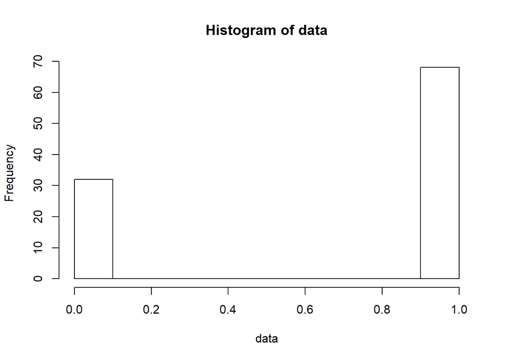

```r
#Generamos 100 nºs aleatorios para probabilidad de éxito de 0.7
#Según distribución de Bernoulli
#Lo guardamos en data
rbern(100, prob = 0.7) -> data

#Representamos el histograma de data
hist(data)
```

#### *Ejemplo en Python*

Vete al script de Python del presente tema 5.